# Handwritten Digit Recognition

## Import and load data

```python
from keras.datasets import mnist
```

```python
(x_train, y_train), (x_test, y_test) = mnist.load_data(path='/Users/ngyduong/anaconda3/envs/DeepLearning/lib/python3.7/site-packages/keras/datasets/mnist.npz')
```

## Import packages

```python
import pandas as pd
import numpy as np
import matplotlib
import matplotlib.pyplot as plt
import os

from keras.models import Sequential, load_model
from keras.layers.core import Dense, Dropout, Activation
from keras.utils import np_utils
```

### Set working directory

```python
os.chdir("/Users/ngyduong/Documents/Machine Learning/Deep Learning/MNIST_Handwritten_Digit_Recognition")
```

# Visualising the data

## Some informations about the data

Here we are in a situation of supervised machine learning (deep learning) therefore there is 4 subsets of the original data set.

```python
print('x_train shape :', x_train.shape)
print('y_train shape :', y_train.shape)
print('x_test shape :', x_test.shape)
print('y_test shape :', y_test.shape)
```

```
x_train shape : (60000, 28, 28)
y_train shape : (60000,)
x_test shape : (10000, 28, 28)
y_test shape : (10000,)
```

There is first the x_train data set which is only the input of the training data set of length 60000 in which each "observation" is an image transformed into a 28x28 pixel matrix.

Then we have the y_train data set which is only the label for each of the images in the x_train data set.

The same logic applies to the x_test and y_test data sets but with only 10000 observations.

## Plotting the data

Here, we will look at the six first observations from the training datasets (x_train and y_train).

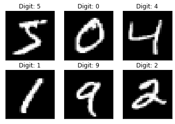

```python
for i in range(6):
    plt.subplot(2,3,i+1) # we create 6 empty subplots
    plt.imshow(x_train[i], cmap = 'gray')
    plt.xticks([]) # remove x scales
    plt.yticks([]) # remove y scales
    plt.title("Digit: {}".format(y_train[i])) # Give titles to each subplots
```

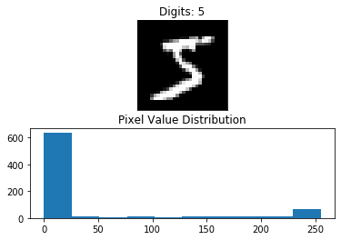

```python
plt.subplot(2,1,1) # create 1st subplot with index 1
plt.imshow(x_train[0], cmap='gray')
plt.title('Digits: {}'.format(y_train[0]))
plt.xticks([])
plt.yticks([])
plt.subplot(2,1,2) # create 2nd subplot with index 1
plt.hist(x_train[0].reshape(784)) # 28x28 = 784
plt.title('Pixel Value Distribution')
```

We have to know that for each image the higher the number of an array means that the whiter (or simply more activate) the pixel is. Which is why we can see with this given histogram that most of the array are of value around 0 (the background) and only a few around 250 (the actual digit number).

## Transform the data

### Transform x_train and x_test

Since the x_train and x_test are composed of only 28x28 pixel matrix we need to transform the data by reshaping it in order for the it to be usable in neural network algorithm.

```python
x_train = x_train.reshape(60000, 784).astype('float32')
x_test = x_test.reshape(10000, 784).astype('float32')
```

Now we have x_train and y_train data sets as arrays of vectors for each image and not 28x28 pixel matrix anymore. We will now normalize the data by dividing it into the max RGB.

```python
x_train /= max(x_train[0])
x_test /= max(x_test[0])
```

```python
print('New x_train shape :', x_train.shape)
print('New x_test shape :', x_test.shape)
```

```
New x_train shape : (60000, 784)
New x_test shape : (10000, 784)
```

As you can see now we have 60000 and 10000 arrays in which each "observation" is a vector of length 784 representing the 784 pixels.

### Transform y_train and y_test

We need to transform the values in the y_train and y_test data sets into categorical variables.

```python
Y_train = pd.get_dummies(y_train, "digit", "_")
Y_test = pd.get_dummies(y_test, "digit", "_")
```

```python
print('New Y_train shape :', y_train.shape)
print('New Y_test shape :', y_test.shape)
```

```
New Y_train shape : (60000,)
New Y_test shape : (10000,)
```

## Building the network

```python
model = Sequential()

# First hidden layers of 512 node
model.add(Dense(512, input_shape=(784,)))
model.add(Activation('relu')) # Rectified Linear Unit : max(x,0)
model.add(Dropout(0.2)) # 20% chance to set an activation node to 0

# Second hidden layers of 512 node
model.add(Dense(512))
model.add(Activation('relu'))
model.add(Dropout(0.2))

# Final visible layer with the 10 categorical variables from 0 to 9
model.add(Dense(10))
model.add(Activation('softmax'))
```

## Training the model

### Compiling the sequential model

```python
model.compile(loss = 'categorical_crossentropy',
              metrics = ['accuracy'], optimizer = 'adam')
```

### Fit the model

```python
model_fit = model.fit(x_train, Y_train,
                      batch_size = 100, # number of samples for one update to the model weights
                      epochs = 10, # number of iteration
                      verbose = 2, validation_data = (x_test, Y_test))
```

```
Train on 60000 samples, validate on 10000 samples
 - 8s - loss: 0.2378 - accuracy: 0.9278 - val_loss: 0.1046 - val_accuracy: 0.9674
 - 8s - loss: 0.0989 - accuracy: 0.9697 - val_loss: 0.0790 - val_accuracy: 0.9752
 - 11s - loss: 0.0721 - accuracy: 0.9777 - val_loss: 0.0783 - val_accuracy: 0.9771
 - 9s - loss: 0.0553 - accuracy: 0.9827 - val_loss: 0.0670 - val_accuracy: 0.9794
 - 9s - loss: 0.0467 - accuracy: 0.9841 - val_loss: 0.0601 - val_accuracy: 0.9823
 - 8s - loss: 0.0395 - accuracy: 0.9871 - val_loss: 0.0672 - val_accuracy: 0.9804
 - 9s - loss: 0.0344 - accuracy: 0.9884 - val_loss: 0.0819 - val_accuracy: 0.9782
 - 9s - loss: 0.0312 - accuracy: 0.9901 - val_loss: 0.0896 - val_accuracy: 0.9770
 - 10s - loss: 0.0294 - accuracy: 0.9900 - val_loss: 0.0826 - val_accuracy: 0.9808
 - 8s - loss: 0.0274 - accuracy: 0.9909 - val_loss: 0.0803 - val_accuracy: 0.9808
```

### Plotting the metrics

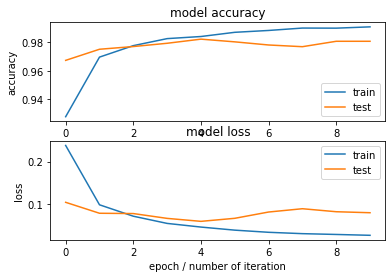

```python
plt.subplot(2,1,1)
plt.plot(model_fit.history['accuracy'])
plt.plot(model_fit.history['val_accuracy'])
plt.title('model accuracy')
plt.xlabel('epoch / number of iteration')
plt.ylabel('accuracy')
plt.legend(['train','test'], loc='lower right')

plt.subplot(2,1,2)
plt.plot(model_fit.history['loss'])
plt.plot(model_fit.history['val_loss'])
plt.title('model loss')
plt.xlabel('epoch / number of iteration')
plt.ylabel('loss')
plt.legend(['train','test'], loc='upper right')
```

### Save the model

```python
model.save(os.path.join(os.getcwd(),'mnist_model.h5'))
```

## Evaluate model performance

### Load the model

```python
mnist_model = load_model('mnist_model.h5')
```

### Get the loss and accuracy

```python
loss_and_metrics = mnist_model.evaluate(x_test, Y_test,
                                        verbose=2)

print("The test loss is {}".format(loss_and_metrics[0]))
print("The test accuracy is {}".format(loss_and_metrics[1]))
```

```
The test loss is 0.08026687926339682
The test accuracy is 0.9807999730110168
```

### Evaluate the correct and incorrect classification examples

```python
predicted_classes = mnist_model.predict_classes(x_test)

correct_indices = np.nonzero(predicted_classes == y_test)[0]
incorrect_indices = np.nonzero(predicted_classes != y_test)[0]

print('classified correctly {}'.format(len(correct_indices)))
print('classified incorrectly {}'.format(len(incorrect_indices)))
```

```
classified correctly 9808
classified incorrectly 192
```

### Plot 9 correct prediction

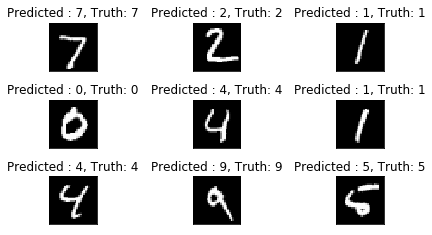

```python
for i, correct in enumerate(correct_indices[:9]):
    plt.subplot(3,3,i+1)
    plt.subplots_adjust(wspace = 2)
    plt.imshow(x_test[correct].reshape(28,28), cmap = 'gray')
    plt.title("Predicted : {}, Truth: {}".format(predicted_classes[correct],
                                                 y_test[correct]))
    plt.xticks([])
    plt.yticks([])
```

### Plot 9 incorrect prediction

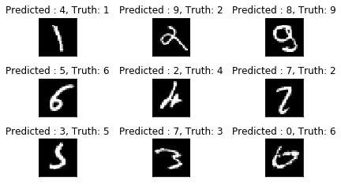

```python
for j, incorrect in enumerate(incorrect_indices[:9]):
    plt.subplot(3,3,j+1)
    plt.subplots_adjust(wspace = 2)
    plt.imshow(x_test[incorrect].reshape(28,28), cmap = 'gray')
    plt.title("Predicted : {}, Truth: {}".format(predicted_classes[incorrect],
                                                 y_test[incorrect]))
    plt.xticks([])
    plt.yticks([])
```